# Búsquedas programáticas en la base de datos ENA

Última actualización:

15 de abril de 2026

# Preparación

En esta práctica vamos a utilizar los paquetes `curl` y `kableExtra` de R.

# Objetivos

1. Aprender a usar la API[^1] de [ENA](https://www.ebi.ac.uk/ena).

# Introducción

La base de datos ENA almacena diferentes tipos de secuencias nucleotídicas, y mucha información sobre cada uno de los *registros*. Desde la línea de comandos o desde un lenguaje de programación cualquiera podemos descargar tanto **metadatos**, mediante la API del *portal* de ENA; como **registros** (es decir, secuencias y la información que las acompaña), mediante la API del *navegador* (*browser*) de ENA.

La API del *portal* de ENA es una sintaxis para la confección de direcciones URL, con las cuales consultamos metadatos de los registros en la base de datos.

En el enlace siguiente encontrarás documentación sobre cómo realizar búsquedas avanzadas en ENA programáticamente usando esta API:

https://ena-docs.readthedocs.io/en/latest/retrieval/programmatic-access/advanced-search.html

Puedes también descargar un manual completo y actualizado de la ENA Portal API en el enlace siguiente: https://www.ebi.ac.uk/ena/portal/api/doc.

Tienes un ejemplo en la URL siguiente. Cópiala, pégala en la barra del navegador y accederás a una tabla que describe los registros de tipo *read run* (lecturas cortas) procedentes del estómago de vacas del Reino Unido:

```
https://www.ebi.ac.uk/ena/portal/api/search?result=read_run&query=country="United Kingdom" AND host_tax_id=9913 AND host_body_site="rumen"
```

Para extraer directamente las secuencias y su información asociada, ENA nos ofrece otro portal, con una API muy parecida: el ENA Browser Portal, cuya documentación deberíamos poder descargar de aquí: https://www.ebi.ac.uk/ena/browser/api/doc.

Como ejemplo, el enlace siguiente te permite descargar la secuencia del cromosoma mitocondrial de un neandertal.

`https://www.ebi.ac.uk/ena/browser/api/fasta/KJ533544`

Como ves, para poder descargar una secuencia (o más) necesitas conocer su número de acceso; KJ533544 en el ejemplo.

# La API del portal de ENA

Cualquier consulta dirigida al portal de ENA tomará la forma de una URL con la estructura siguiente:

1. La dirección del portal: `https://www.ebi.ac.uk/ena/portal/api`.
2. El **endpoint** `/search`, que especifica que realizamos una consulta o búsqueda. Existen otros *endpoints*.
3. Los parámetros de la búsqueda, que incluyen cinco campos separados por “&”:
- `/result=<tipo de datos>`, donde `<tipo de datos>` puede ser cualquiera de los *results* disponibles: *read_run*, *read_experiment*, *sample*, *study*, *sequence_release*, *sequence_update*, *wgs_set*, *tsa_set*, *assembly*, *coding_release*, *coding_update*, *noncoding_release*, *noncoding_update*, y *taxonomy*.
- Opcionalmente, `query=<filtros>`, donde `<filtros>` debe sustituirse por una o más condiciones que deben cumplir los registros para ser presentados. Las diferentes condiciones o filtros irán separadas por “AND”, “OR” o “NOT”. Existen reglas sobre cómo especificar cada posible filtro para cada posible tipo de resultado. Estas reglas están especificadas en la documentación del portal: https://www.ebi.ac.uk/ena/portal/api/doc.
- Opcionalmente, `fields=<campos>`, donde `<campos>` se debe sustituir por la lista, separada por comas, de los campos de información que deseamos extraer de cada registro. Es decir, las columnas que deseamos ver en la tabla de resultados. Cada tipo de `result` admite un conjunto de campos disponibles, que también están detallados en la documentación del portal.
- Opcionalmente, `limit=<límite>` donde `<límite>` representa el número máximo de registros (líneas) que queremos extraer en la tabla de resultados. Por defecto, el límite es 100000. Para no limitar la búsqueda, hay que especificar `limit=0`.
- Opcionalmente, `format=<formato>`, donde `<formato>` representa uno de dos valores posibles: `tsv` (*tab separated values*, usado por defecto) o `json`.

### Ejemplos

```
https://www.ebi.ac.uk/ena/portal/api/search?result=sequence&query=(specimen_voucher="ZMB:Moll:*" OR bio_material="ZMB:Moll:*")&fields=specimen_voucher,bio_material,scientific_name
```

```
https://www.ebi.ac.uk/ena/portal/api/search?result=analysis&query=country="United Kingdom" AND host_tax_id=9913 AND host_body_site="rumen" AND analysis_type="SEQUENCE_ASSEMBLY" AND assembly_type="primary metagenome"&fields=submitted_ftp
```

```
https://www.ebi.ac.uk/ena/portal/api/search?result=assembly&query=tax_tree(6157) AND genome_representation="full"&fields=version,tax_id,scientific_name,last_updated,base_count&limit=0
```

# Desde una sesión de R

La función `read.table()` puede leer directamente de una página web. Pero si queremos descargar el resultado de una consulta programática en un archivo, podemos usar el paquete la función `curl_download()`, del paquete `curl`.

```r
library('curl')
```

**Ejercicio 1**

Intenta ejecutar los bloques siguientes. Compáralos y explica qué problemas o dificultades identificas en cada uno.

```r
curl_download('https://www.ebi.ac.uk/ena/portal/api/search?result=assembly&query=tax_tree(6157)%20AND%20genome_representation="full"&fields=version,tax_id,scientific_name,last_updated,base_count&limit=0',
              destfile = 'z1.txt')
```

```
Error in `curl_download()`:
! HTTP response code said error [www.ebi.ac.uk]:
The requested URL returned error: 400
```

En el primer bloque el enlace no está correctamente formatedo, presenta espacios, comas, etc. El segundo bloque se formatea bien gracias al código URLencode. La ventaja del tercer bloque es que es más visual y es más fácil de identificar en la búsqueda.

```r
curl_download(
  URLencode('https://www.ebi.ac.uk/ena/portal/api/search?result=assembly&query=tax_tree(6157) AND genome_representation="full"&fields=version,tax_id,scientific_name,last_updated,base_count&limit=0'),
  destfile = 'z1.txt')
```

```r
portal <- 'https://www.ebi.ac.uk/ena/portal/api/search?'
result <- 'result=assembly&'
query  <- 'query=tax_tree(6157) AND genome_representation="full"&'
fields <- 'fields=version,tax_id,scientific_name,last_updated,base_count&'
limit  <- 'limit=0'
URL <- paste0(portal, result, query, fields, limit)
curl_download(URLencode(URL), destfile = 'z2.txt')
```

**Ejercicio 2**

Confecciona una URL para descargar una tabla de las secuencias codificantes de alcohol deshidrogenasas del género *Drosophila*, que te permita contestar las preguntas siguientes. Consulta el apéndice de este guión, si lo necesitas.

```r
portal <- 'https://www.ebi.ac.uk/ena/portal/api/search?'
result <- 'result=sequence&'
query  <- 'query=tax_tree(7215) AND description="alcohol dehydrogenase"&'
fields <- 'fields=accession,tax_id,scientific_name,base_count,first_public,description&'
limit  <- 'limit=0'
format <- 'format=tsv&'
URL1 <- paste0(portal, result, query, fields, format, limit)
curl_download(URLencode(URL1), destfile = 'z3.txt')
```

En primer lugar, nombramos el objeto adh:

```r
adh <- read.table('z3.txt', quote = "", header = TRUE, sep ="\t")
```

1. ¿Cuántas secuencias hay con el término “alcohol dehydrogenase” en su descripción?

```r
dim(adh)
```

```
[1] 1258    6
```

2. ¿Qué longitudes tienen? La media sería la longitud que tienen.

```r
summary(adh$base_count)
```

```
   Min. 1st Qu.  Median    Mean 3rd Qu.    Max.
     44     590     839    1252     967   17499
```

3. ¿De cuántas especies diferentes son estas secuencias?

```r
length(unique(adh$scientific_name))
```

```
[1] 308
```

4. ¿Cuándo se publicaron las más recientes?

```r
tail(sort(adh$first_public))
```

```
[1] "2019-06-04" "2019-06-04" "2019-06-04" "2019-06-04" "2019-06-04"
[6] "2022-04-03"
```

# Trabajar con los resultados

La función `read.table()` de R nos permite leer un archivo (o una URL) para crear una tabla. Necesita que todas las filas tengan el mismo número de campos o columnas, delimitadas por el carácter especificado con la opción `sep = "\t"`. Esta función nos permite también especificar el tipo de datos de cada columna. Podemos usar como ejemplo los genomas de platelmintos del ejercicio 1:

```r
# Si no has ejecutado el tercer bloque del ejercicio 1,
# la variable URL no estará definida.
platelmintos <- read.table(URLencode(URL),
    header = TRUE,
    colClasses = c('numeric', 'factor', 'character', 'Date', 'numeric', 'character'),
    sep = '\t',
    na.strings = '')
```

El código siguiente crea una nueva columna en la tabla con el género al que pertenece cada secuencia. Se toma como género la primera palabra del nombre científico. Para ello, debemos separar las partes de cada nombre delimitadas por un espacio en blanco, con la función `strsplit()`. Y por último usamos la función `sapply()` para aplicar a cada nombre científico la función de selección de componentes, `[`, y la opción “1”, para seleccionar sólo el primero de los componentes en que habíamos dividido cada nombre científico.

```r
platelmintos$genus <- sapply(
   strsplit(platelmintos$scientific_name, ' '),
   '[',
   1)
```

Una vez clasificadas por género, podemos visualizar el número de bases de cada secuencia agrupadas por género.

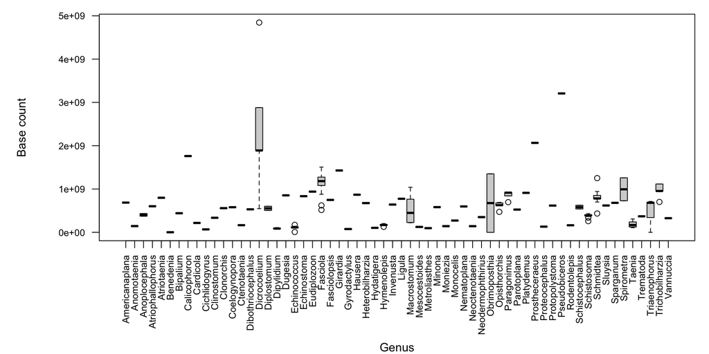

```r
par(mar = c(8,7,1,1))
boxplot(base_count ~ genus, data = platelmintos,
        las = 2, xlab = '', ylab = '', cex.axis = 0.8)
mtext('Genus', side = 1, line = 7)
mtext('Base count', side = 2, line = 5)
```

**Ejercicio 3**

¿De qué manera necesitarías transformar la tabla `platelmintos` para poder representar gráficamente la longitud acumulada de todas las secuencias disponibles a medida que se han ido publicando?

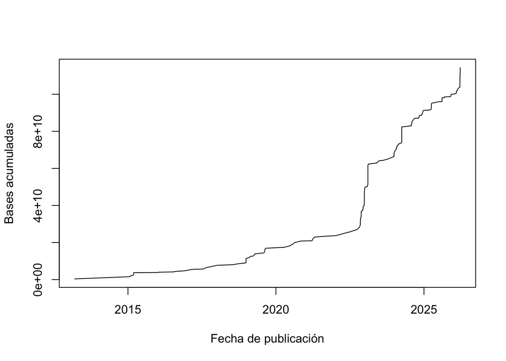

```r
# Ordenar la tabla por fecha de publicación
platelmintos <- platelmintos[order(platelmintos$last_updated), ]
# Crear una nueva columna con la suma acumulada de bases
platelmintos$base_acumuladas <- cumsum(platelmintos$base_count)
# Representar la longitud acumulada a lo largo del tiempo
plot(platelmintos$last_updated, platelmintos$base_acumuladas,
     type = "l",
     xlab = "Fecha de publicación",
     ylab = "Bases acumuladas")
```

# La API del navegador (*browser*) de ENA

Entre las secuencias obtenidas en el ejercicio 2, encontrarás las siguientes: AAC39011, AAY25307, ABU44510, ABG56046 y AAO06902. Vamos a descargarlas en formato fasta:

```r
portal    <- 'https://www.ebi.ac.uk/ena/browser/api/'
formato   <- 'fasta/'
accession <- 'AAC39011,AAY25307,ABU44510,ABG56046,AAO06902'
URL <- paste0(portal, formato, accession)
URL
```

```
[1] "https://www.ebi.ac.uk/ena/browser/api/fasta/AAC39011,AAY25307,ABU44510,ABG56046,AAO06902"
```

```r
curl_download(URL, destfile = 'Adh.fasta')
```

**Ejercicio 4**

Intenta descargar esas mismas secuencias en formato EMBL.

```r
library(curl)
portal    <- 'https://www.ebi.ac.uk/ena/browser/api/'
formato   <- 'embl/'
accession <- 'AAC39011,AAY25307,ABU44510,ABG56046,AAO06902'
URL <- paste0(portal, formato, accession)
URL
```

```
[1] "https://www.ebi.ac.uk/ena/browser/api/embl/AAC39011,AAY25307,ABU44510,ABG56046,AAO06902"
```

```r
curl_download(URL, destfile = 'Adh.embl')
```

# Apéndice

## Campos de información para filtrar la búsqueda de resultados de tipo *coding*

```r
library('knitr')
URL <- 'https://www.ebi.ac.uk/ena/portal/api/searchFields?result=coding'
CodingSearchFields <- read.table(URL, header = TRUE, sep = '\t')
kable(CodingSearchFields)
```

| columnId | description | type |
| --- | --- | --- |
| accession | accession number | text |
| allele | name of the allele for the given gene | text |
| altitude | Altitude (m) | number |
| artificial_location | indicates location is modified to adjust for the presence of a frameshift or internal stop codon | controlled value |
| base_count | number of base pairs | number |
| bio_material | identifier for biological material including institute and collection code | text |
| cell_line | cell line from which the sample was obtained | text |
| cell_type | cell type from which the sample was obtained | text |
| codon_start | indicates the offset of the first complete codon relative to the first base of the coding feature | controlled value |
| collected_by | name of the person who collected the specimen | text |
| country | locality of sample isolation: country names, oceans or seas, followed by regions and localities | text |
| cultivar | cultivar (cultivated variety) of plant from which sample was obtained | text |
| culture_collection | identifier for the sample culture including institute and collection code | text |
| dataclass | sequence data class | controlled value |
| description | brief sequence description | text |
| dev_stage | sample obtained from an organism in a specific developmental stage | text |
| ec_number | Enzyme Commission number for enzyme product of sequence | text |
| ecotype | a population within a given species displaying traits that reflect adaptation to a local habitat | text |
| environmental_sample | identifies sequences derived by direct molecular isolation from an environmental DNA sample | boolean |
| exception | indicates that the coding region cannot be translated using standard biological rules | text |
| experiment | a brief description of the nature of the experimental evidence | text |
| first_public | date when made public | date |
| function | function attributed to a sequence | text |
| gene | symbol of the gene corresponding to a sequence region | text |
| gene_synonym | synonymous, replaced, obsolete or former gene symbol | text |
| germline | the sample is an unrearranged molecule that was inherited from the parental germline | boolean |
| haplotype | combination of alleles that are linked together on the same physical chromosome | text |
| host | natural (as opposed to laboratory) host to the organism from which sample was obtained | text |
| identified_by | name of the taxonomist who identified the specimen | text |
| indexed_date | date when record was indexed for presentation | date |
| inference | a structured description of non-experimental evidence | text |
| isolate | individual isolate from which sample was obtained | text |
| isolation_source | describes the physical, environmental and/or local geographical source of the sample | text |
| keywords | keywords associated with sequence | text |
| lab_host | scientific name of the laboratory host used to propagate the source organism for the sample | text |
| last_updated | date when last updated | date |
| location | geographic location of isolation of the sample | latlon |
| locus_tag | a submitter-supplied, systematic, stable identifier for a gene and its associated features | text |
| map | genomic map position of feature | text |
| marker | marker classification | indexed |
| mating_type | mating type of the organism from which the sequence was obtained | text |
| mol_type | in vivo molecule type of the sequence | controlled value |
| old_locus_tag | deprecated submitter-supplied, systematic, stable identifier for a gene and its associated features | text |
| operon | name of the group of contiguous genes transcribed into a single transcript | text |
| organelle | membrane-bound intracellular structure from which the sequence was obtained | controlled value |
| parent_accession | parent sequence accession number | text |
| plasmid | name of naturally occurring plasmid from which the sequence was obtained | text |
| product | name of the product associated with the feature | text |
| protein_id | a stable protein identifier issued by INSDC | text |
| pseudo | the feature is non-functional | boolean |
| pseudo_gene | indicates that this feature is a pseudogene | text |
| ribosomal_slippage | indicates ribosomal slippage (change to an alternative reading frame) during protein translation | boolean |
| sample_accession | sample accession number | text |
| scientific_name | scientific name of an organism | text |
| sequence_md5 | MD5 checksum of sequence | text |
| sequence_version | Version of the sequence | number |
| serotype | serological variety of a species characterized by its antigenic properties | text |
| serovar | serological variety of a species (usually a prokaryote) characterized by its antigenic properties | text |
| sex | sex of the organism from which the sample was obtained | controlled value |
| specimen_voucher | identifier for the sample culture including institute and collection code | text |
| standard_name | accepted standard name for a feature | text |
| status | Status | number |
| strain | strain from which sample was obtained | text |
| study_accession | study accession number | text |
| sub_species | name of sub-species of organism from which sample was obtained | text |
| sub_strain | name or identifier of a genetically or otherwise modified strain from which sample was obtained | text |
| tag | Classification Tags | controlled value |
| tax_division | taxonomic division | controlled value |
| tax_id | NCBI taxonomic classification | taxonomy |
| tissue_lib | tissue library from which sample was obtained | text |
| tissue_type | tissue type from which the sample was obtained | text |
| topology | sequence topology: circular or linear | controlled value |
| trans_splicing | indicates exons from two RNA molecules are ligated in intermolecular reaction to form mature RNA | boolean |
| transl_except | a single codon translation that does not conform to genetic code | text |
| transl_table | indicates the genetic code table used if other than universal genetic code table | controlled value |
| variety | variety (varietas, a formal Linnaean rank) of organism from which sample was derived | text |